# Phase 4: Clustering Analysis (StandardKMeans)

This project was done by Hossein Hamzehei and Mahdi Samdi Azar for the course named Data Science & AI Introductory Course with Python, conducted by the Department of Mathematical Sciences, Sharif University of Technology.

**Dataset**: Divar Real Estate Advertisements (1M records)

## Objective

Segment the real estate market into distinct, interpretable categories that provide business value beyond simple statistics.

## Analysis Scope

1. **Data Loading & Feature Selection** - Select relevant features for clustering
2. **Preprocessing** - Handle missing values, outliers, normalization
3. **Optimal K Selection** - Elbow and Silhouette methods
4. **Approach 1: Cluster Original Features** - K-Means with PCA visualization
5. **Approach 2: Cluster PCA Components** - Compare with Approach 1
6. **t-SNE Visualization** - Multiple runs to verify robust patterns
7. **Cluster Interpretation** - Assign business-meaningful names
8. **Results & Export** - Save cluster assignments and profiles

## 1. Setup and Library Imports

```python
import os

THREAD_COUNT = str(os.cpu_count() or 1)
os.environ.setdefault('OMP_NUM_THREADS', THREAD_COUNT)
os.environ.setdefault('OPENBLAS_NUM_THREADS', THREAD_COUNT)
os.environ.setdefault('MKL_NUM_THREADS', THREAD_COUNT)
os.environ.setdefault('NUMEXPR_NUM_THREADS', THREAD_COUNT)
os.environ.setdefault('ARROW_NUM_THREADS', THREAD_COUNT)

import pandas as pd
import numpy as np
import matplotlib.pyplot as plt
import seaborn as sns
from pathlib import Path
import warnings
warnings.filterwarnings('ignore')

pd.options.compute.use_numexpr = True
pd.options.compute.use_bottleneck = True

# Clustering and preprocessing
from sklearn.cluster import KMeans, MiniBatchKMeans
from sklearn.preprocessing import StandardScaler
from sklearn.decomposition import PCA
from sklearn.manifold import TSNE
from sklearn.metrics import silhouette_score, silhouette_samples

# Display settings
pd.set_option('display.max_columns', None)
pd.set_option('display.max_rows', 100)
pd.set_option('display.float_format', lambda x: '%.2f' % x)

# Plot styling (consistent with previous phases)
plt.rcParams['figure.figsize'] = (12, 6)
plt.rcParams['font.size'] = 10
plt.rcParams['axes.titlesize'] = 12
plt.rcParams['axes.labelsize'] = 10
sns.set_style('whitegrid')

# Color palette
COLORS = {
    'primary': '#2ecc71',
    'secondary': '#3498db',
    'accent': '#e74c3c',
    'neutral': '#95a5a6',
    'purple': '#9b59b6',
    'orange': '#e67e22',
    'teal': '#1abc9c'
}

# Cluster colors (for consistent visualization) - extended to support up to 10 clusters
CLUSTER_COLORS = ['#e74c3c', '#3498db', '#2ecc71', '#9b59b6', '#e67e22',
                  '#1abc9c', '#f39c12', '#34495e', '#e91e63', '#00bcd4']

print("Libraries loaded successfully")

def read_csv_fast(path, **kwargs):
    parquet_path = path.with_suffix('.parquet')
    if parquet_path.exists():
        print(f"Loading Parquet: {parquet_path}")
        return pd.read_parquet(parquet_path)
    try:
        return pd.read_csv(path, engine='pyarrow', **kwargs)
    except Exception as exc:
        print(f"PyArrow CSV engine unavailable for {path.name}; falling back to pandas C engine ({exc})")
        return pd.read_csv(path, low_memory=False, **kwargs)
```

```
Libraries loaded successfully
```

## 2. Project Structure and Data Loading

```python
# Define project paths
import os

def find_project_root(start=None):
    start = (start or Path.cwd()).resolve()
    for path in (start, *start.parents):
        if (path / 'Divar-Real-State-Ads').exists() and (path / 'notebooks').exists():
            return path
    raise FileNotFoundError("Could not locate project root.")


PROJECT_ROOT = find_project_root()

REPORTS_PATH = PROJECT_ROOT / 'reports'
DATA_PROCESSED = REPORTS_PATH / 'data'
FIGURES_PATH = REPORTS_PATH / 'figures'
MODELS_PATH = REPORTS_PATH / 'models'

# Create directories
DATA_PROCESSED.mkdir(parents=True, exist_ok=True)
FIGURES_PATH.mkdir(parents=True, exist_ok=True)
MODELS_PATH.mkdir(parents=True, exist_ok=True)

print(f"Project root: {PROJECT_ROOT}")
print(f"Figures path: {FIGURES_PATH}")
print(f"Figures path exists: {FIGURES_PATH.exists()}")
```

```
Project root: .
Figures path: ./reports/figures
Figures path exists: True
```

```python
# Load the enhanced dataset from Phase 2
DATA_FILE = DATA_PROCESSED / 'cleaned_data_with_features.csv'

print(f"Loading data from: {DATA_FILE}")
df_full = read_csv_fast(DATA_FILE)
print(f"Full dataset: {len(df_full):,} rows")

# Filter to sale listings only (clustering for sale market)
df = df_full[df_full['listing_type'] == 'sell'].copy()
print(f"Sale listings: {len(df):,} rows")
```

```
Loading data from: ./reports/data/cleaned_data_with_features.csv
Loading Parquet: ./reports/data/cleaned_data_with_features.parquet
```

```
Full dataset: 1,000,000 rows
```

```
Sale listings: 597,569 rows
```

## 3. Feature Selection and Engineering

We select features that are meaningful for market segmentation:

- **Price per sqm**: Core value metric
- **Building size**: Property size
- **Room count**: Property configuration
- **Amenities**: Elevator, parking, storage
- **City**: Location factor (target encoded by median price)

```python
# Ensure numeric types
df['price_value'] = pd.to_numeric(df['price_value'], errors='coerce')
df['building_size'] = pd.to_numeric(df['building_size'], errors='coerce')
df['price_per_sqm'] = pd.to_numeric(df['price_per_sqm'], errors='coerce')

# Convert rooms_count to numeric
room_mapping = {
    'بدون اتاق': 0,
    'یک': 1,
    'دو': 2,
    'سه': 3,
    'چهار': 4,
    'پنج یا بیشتر': 5
}
df['rooms_numeric'] = df['rooms_count'].map(room_mapping)

# Convert amenities to binary (handle various formats)
for col in ['has_elevator', 'has_parking', 'has_warehouse']:
    if col in df.columns:
        # Convert to string first, then check for True/true/1
        df[col + '_binary'] = df[col].astype(str).str.lower().isin(['true', '1', '1.0']).astype(int)

print("Feature engineering complete")
print(f"\nFeature availability:")
print(f"  price_per_sqm: {df['price_per_sqm'].notna().sum():,} valid ({df['price_per_sqm'].notna().mean()*100:.1f}%)")
print(f"  building_size: {df['building_size'].notna().sum():,} valid ({df['building_size'].notna().mean()*100:.1f}%)")
print(f"  rooms_numeric: {df['rooms_numeric'].notna().sum():,} valid ({df['rooms_numeric'].notna().mean()*100:.1f}%)")
```

```
Feature engineering complete

Feature availability:
  price_per_sqm: 565,157 valid (94.6%)
  building_size: 597,508 valid (100.0%)
  rooms_numeric: 463,387 valid (77.5%)
```

### 3.1 City Target Encoding

We encode city by its median price per sqm. This creates a single numeric feature that captures the "price level" of each location.

```python
# Calculate median price per sqm for each city
city_price_median = df.groupby('city_slug')['price_per_sqm'].median()

# Target encode: replace city name with its median price
df['city_price_level'] = df['city_slug'].map(city_price_median)

# Show encoding for top cities
print("City Target Encoding (by median price/sqm):")
print("=" * 50)
top_cities = city_price_median.sort_values(ascending=False).head(10)
for city, price in top_cities.items():
    if pd.notna(price):
        city_name = city.replace('-', ' ').title()
        print(f"{city_name:<25} -> {price/1e6:.1f}M Tomans/sqm")

print(f"\nCity price level: {df['city_price_level'].notna().sum():,} valid")
```

```
City Target Encoding (by median price/sqm):
==================================================
Kish                      -> 100.0M Tomans/sqm
Tehran                    -> 85.7M Tomans/sqm
Fasham City               -> 61.3M Tomans/sqm
Lavasan City              -> 60.0M Tomans/sqm
Shemshak                  -> 53.8M Tomans/sqm
Salman Shahr              -> 50.0M Tomans/sqm
Garmdareh                 -> 43.4M Tomans/sqm
Shiraz                    -> 37.0M Tomans/sqm
Lahijan                   -> 35.2M Tomans/sqm
Isfahan                   -> 35.0M Tomans/sqm

City price level: 597,567 valid
```

## 4. Data Preprocessing

Following instructor guidance: normalize features with different scales.

### 4.1 Select Features and Handle Missing Values

```python
# Define clustering features (only features with good availability)
clustering_features = [
    'price_per_sqm',
    'building_size',
    'rooms_numeric',
    'has_elevator_binary',
    'has_parking_binary',
    'has_warehouse_binary',
    'city_price_level'
]

# Check availability
print("Feature Availability:")
print("=" * 50)
for feat in clustering_features:
    if feat in df.columns:
        valid = df[feat].notna().sum()
        pct = valid / len(df) * 100
        print(f"{feat:<25} {valid:>10,} ({pct:>5.1f}%)")
    else:
        print(f"{feat:<25} MISSING COLUMN")
```

```
Feature Availability:
==================================================
price_per_sqm                565,157 ( 94.6%)
building_size                597,508 (100.0%)
rooms_numeric                463,387 ( 77.5%)
has_elevator_binary          597,569 (100.0%)
has_parking_binary           597,569 (100.0%)
has_warehouse_binary         597,569 (100.0%)
city_price_level             597,567 (100.0%)
```

```python
# Create clustering dataset
# Start with essential features that have high availability
essential_features = ['price_per_sqm', 'building_size', 'city_price_level']

# Filter: must have essential features
df_cluster = df[df['price_per_sqm'].notna() & df['building_size'].notna()].copy()
print(f"After requiring price_per_sqm and building_size: {len(df_cluster):,} rows")

# Apply reasonable bounds (same as Phase 3)
df_cluster = df_cluster[
    (df_cluster['price_per_sqm'] >= 5_000_000) &
    (df_cluster['price_per_sqm'] <= 500_000_000) &
    (df_cluster['building_size'] >= 20) &
    (df_cluster['building_size'] <= 1000)
].copy()
print(f"After outlier removal: {len(df_cluster):,} rows")

# Impute missing values for other features with median
df_cluster['rooms_numeric'] = df_cluster['rooms_numeric'].fillna(df_cluster['rooms_numeric'].median())
df_cluster['city_price_level'] = df_cluster['city_price_level'].fillna(df_cluster['city_price_level'].median())

# Binary features: fill missing with 0 (assume no amenity if not specified)
for col in ['has_elevator_binary', 'has_parking_binary', 'has_warehouse_binary']:
    if col in df_cluster.columns:
        df_cluster[col] = df_cluster[col].fillna(0).astype(int)

print(f"\nFinal clustering dataset: {len(df_cluster):,} rows")
```

```
After requiring price_per_sqm and building_size: 565,157 rows
```

```
After outlier removal: 468,402 rows

Final clustering dataset: 468,402 rows
```

### 4.2 Log Transformation for Skewed Variables

```python
# Check skewness before transformation
print("Skewness before log transformation:")
print(f"  price_per_sqm: {df_cluster['price_per_sqm'].skew():.2f}")
print(f"  building_size: {df_cluster['building_size'].skew():.2f}")
print(f"  city_price_level: {df_cluster['city_price_level'].skew():.2f}")

# Apply log transformation to highly skewed variables
df_cluster['log_price_per_sqm'] = np.log1p(df_cluster['price_per_sqm'])
df_cluster['log_building_size'] = np.log1p(df_cluster['building_size'])
df_cluster['log_city_price_level'] = np.log1p(df_cluster['city_price_level'])

print("\nSkewness after log transformation:")
print(f"  log_price_per_sqm: {df_cluster['log_price_per_sqm'].skew():.2f}")
print(f"  log_building_size: {df_cluster['log_building_size'].skew():.2f}")
print(f"  log_city_price_level: {df_cluster['log_city_price_level'].skew():.2f}")
```

```
Skewness before log transformation:
  price_per_sqm: 3.31
  building_size: 3.69
  city_price_level: 1.14

Skewness after log transformation:
  log_price_per_sqm: 0.22
  log_building_size: 0.64
  log_city_price_level: -0.15
```

### 4.3 Feature Normalization

As per instructor guidance: normalize features with different scales.

```python
# Final features for clustering (using log-transformed where applicable)
final_features = [
    'log_price_per_sqm',
    'log_building_size',
    'rooms_numeric',
    'has_elevator_binary',
    'has_parking_binary',
    'has_warehouse_binary',
    'log_city_price_level'
]

# Verify no missing values
print("Final feature check (should all be 0 missing):")
for feat in final_features:
    missing = df_cluster[feat].isna().sum()
    print(f"  {feat}: {missing} missing")

# Extract feature matrix
X = df_cluster[final_features].values
print(f"\nFeature matrix shape: {X.shape}")
```

```
Final feature check (should all be 0 missing):
  log_price_per_sqm: 0 missing
  log_building_size: 0 missing
  rooms_numeric: 0 missing
  has_elevator_binary: 0 missing
  has_parking_binary: 0 missing
  has_warehouse_binary: 0 missing
  log_city_price_level: 0 missing

Feature matrix shape: (468402, 7)
```

```python
# Normalize using StandardScaler
scaler = StandardScaler()
X_scaled = scaler.fit_transform(X)

print("Feature Normalization Complete")
print("=" * 50)
print(f"Shape: {X_scaled.shape}")
print(f"\nScaled feature statistics:")
print(f"  Mean (should be ~0): {X_scaled.mean(axis=0).round(2)}")
print(f"  Std (should be ~1): {X_scaled.std(axis=0).round(2)}")
```

```
Feature Normalization Complete
==================================================
Shape: (468402, 7)

Scaled feature statistics:
  Mean (should be ~0): [-0. -0.  0. -0. -0.  0. -0.]
  Std (should be ~1): [1. 1. 1. 1. 1. 1. 1.]
```

## 5. Optimal Number of Clusters (K)

We use two methods to determine the optimal K:

1. **Elbow Method**: Look for the "elbow" in the inertia plot
2. **Silhouette Method**: Higher score = better cluster separation

```python
# K Selection with Standard KMeans (SLOW but exact)
# WARNING: This takes much longer than MiniBatchKMeans

k_range = range(2, 11)
inertias = []
silhouette_scores = []

# Use sampling for silhouette calculation (O(n^2) is too slow on full data)
SAMPLE_SIZE = 256000
np.random.seed(42)
sample_idx = np.random.choice(len(X_scaled), min(SAMPLE_SIZE, len(X_scaled)), replace=False)
X_sample = X_scaled[sample_idx]

print("Evaluating K values with Standard KMeans...")
print(f"Using {SAMPLE_SIZE:,} samples for silhouette calculation")
print("WARNING: This may take 30-60 minutes!")
print("=" * 50)

for k in k_range:
    # Standard KMeans - slower but exact
    kmeans = KMeans(n_clusters=k, random_state=42, n_init=10, max_iter=300)
    kmeans.fit(X_scaled)

    inertias.append(kmeans.inertia_)

    # Silhouette on sample only (fast)
    sample_labels = kmeans.predict(X_sample)
    sil_score = silhouette_score(X_sample, sample_labels)
    silhouette_scores.append(sil_score)

    print(f"  K={k}: Inertia={kmeans.inertia_:,.0f}, Silhouette={sil_score:.4f}")

print("\n[OK] K evaluation complete!")
```

```
Evaluating K values with Standard KMeans...
Using 256,000 samples for silhouette calculation
WARNING: This may take 30-60 minutes!
==================================================
```

```
  K=2: Inertia=2,485,474, Silhouette=0.2924
```

```
  K=3: Inertia=2,079,756, Silhouette=0.2463
```

```
  K=4: Inertia=1,804,336, Silhouette=0.2680
```

```
  K=5: Inertia=1,588,476, Silhouette=0.2681
```

```
  K=6: Inertia=1,412,648, Silhouette=0.2848
```

```
  K=7: Inertia=1,299,897, Silhouette=0.3004
```

```
  K=8: Inertia=1,204,307, Silhouette=0.3123
```

```
  K=9: Inertia=1,117,059, Silhouette=0.3048
```

```
  K=10: Inertia=1,059,250, Silhouette=0.3030

[OK] K evaluation complete!
```

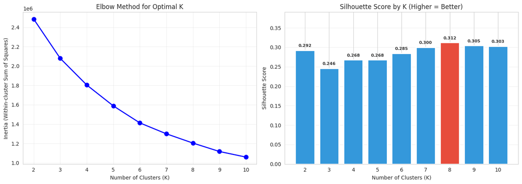

```
Best K by Silhouette Score: 8
Silhouette Score: 0.3123
```

```python
# Visualize Elbow and Silhouette methods
fig, axes = plt.subplots(1, 2, figsize=(14, 5))

# Left: Elbow Method
axes[0].plot(list(k_range), inertias, 'bo-', linewidth=2, markersize=8)
axes[0].set_xlabel('Number of Clusters (K)')
axes[0].set_ylabel('Inertia (Within-cluster Sum of Squares)')
axes[0].set_title('Elbow Method for Optimal K')
axes[0].set_xticks(list(k_range))
axes[0].grid(True, alpha=0.3)

# Right: Silhouette Method
colors = [COLORS['accent'] if s == max(silhouette_scores) else COLORS['secondary'] for s in silhouette_scores]
bars = axes[1].bar(list(k_range), silhouette_scores, color=colors, edgecolor='white', linewidth=2)
axes[1].set_xlabel('Number of Clusters (K)')
axes[1].set_ylabel('Silhouette Score')
axes[1].set_title('Silhouette Score by K (Higher = Better)')
axes[1].set_xticks(list(k_range))
axes[1].grid(True, alpha=0.3, axis='y')

# Labels ABOVE with headroom
max_score = max(silhouette_scores)
axes[1].set_ylim(0, max_score * 1.25)
for bar, score in zip(bars, silhouette_scores):
    axes[1].text(bar.get_x() + bar.get_width()/2, bar.get_height() + max_score * 0.02,
                 f'{score:.3f}', ha='center', va='bottom', fontsize=8, fontweight='bold', color='#333333')

plt.tight_layout()
plt.savefig(FIGURES_PATH / '04_standard_optimal_k_selection.png', dpi=150, bbox_inches='tight')
plt.show()

# Determine optimal K
best_k_silhouette = list(k_range)[np.argmax(silhouette_scores)]
print(f"\nBest K by Silhouette Score: {best_k_silhouette}")
print(f"Silhouette Score: {max(silhouette_scores):.4f}")
```

```python
# Select optimal K based on analysis
optimal_k = best_k_silhouette
print(f"Selected K = {optimal_k} for clustering")
print(f"\nThis creates {optimal_k} distinct market segments.")
```

```
Selected K = 8 for clustering

This creates 8 distinct market segments.
```

## 6. Approach 1: Cluster Original Features, Visualize with PCA

First approach: Run K-Means on the normalized original features, then use PCA for 2D visualization.

```python
# Fit final Standard KMeans model
print(f"Fitting Standard KMeans with K={optimal_k}...")
print("This may take several minutes...")

kmeans_original = KMeans(n_clusters=optimal_k, random_state=42, n_init=10, max_iter=300)
cluster_labels_original = kmeans_original.fit_predict(X_scaled)

# Add cluster labels to dataframe
df_cluster['cluster_original'] = cluster_labels_original

# Check cluster sizes
print(f"\nCluster Sizes (Approach 1 - Standard KMeans):")
print("=" * 40)
cluster_counts = pd.Series(cluster_labels_original).value_counts().sort_index()
for cluster_id, count in cluster_counts.items():
    pct = count / len(cluster_labels_original) * 100
    print(f"  Cluster {cluster_id}: {count:>10,} ({pct:>5.1f}%)")
```

```
Fitting Standard KMeans with K=8...
This may take several minutes...
```

```
Cluster Sizes (Approach 1 - Standard KMeans):
========================================
  Cluster 0:     32,244 (  6.9%)
  Cluster 1:    119,588 ( 25.5%)
  Cluster 2:     40,825 (  8.7%)
  Cluster 3:     76,314 ( 16.3%)
  Cluster 4:     69,104 ( 14.8%)
  Cluster 5:     53,749 ( 11.5%)
  Cluster 6:     45,104 (  9.6%)
  Cluster 7:     31,474 (  6.7%)
```

```python
# PCA for visualization (reduce to 2D)
pca_viz = PCA(n_components=2, random_state=42)
X_pca_2d = pca_viz.fit_transform(X_scaled)

print(f"PCA Explained Variance:")
print(f"  PC1: {pca_viz.explained_variance_ratio_[0]*100:.1f}%")
print(f"  PC2: {pca_viz.explained_variance_ratio_[1]*100:.1f}%")
print(f"  Total: {sum(pca_viz.explained_variance_ratio_)*100:.1f}%")
```

```
PCA Explained Variance:
  PC1: 33.8%
  PC2: 25.3%
  Total: 59.1%
```

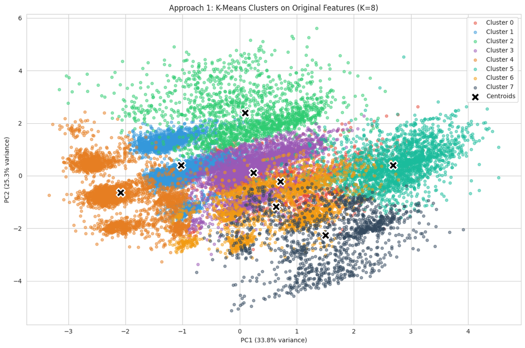

```
Note: Showing 20,000 sampled points for clarity.
```

```python
# Visualize clusters with PCA
fig, ax = plt.subplots(figsize=(12, 8))

# Sample for visualization (too many points obscure patterns)
np.random.seed(42)
sample_size = min(20000, len(X_pca_2d))
sample_idx = np.random.choice(len(X_pca_2d), sample_size, replace=False)

for cluster_id in range(optimal_k):
    mask = (cluster_labels_original[sample_idx] == cluster_id)
    ax.scatter(
        X_pca_2d[sample_idx][mask, 0],
        X_pca_2d[sample_idx][mask, 1],
        c=CLUSTER_COLORS[cluster_id],
        label=f'Cluster {cluster_id}',
        alpha=0.5,
        s=20
    )

# Plot cluster centers
centers_pca = pca_viz.transform(kmeans_original.cluster_centers_)
ax.scatter(centers_pca[:, 0], centers_pca[:, 1], c='black', marker='X', s=200,
           edgecolors='white', linewidths=2, label='Centroids')

ax.set_xlabel(f'PC1 ({pca_viz.explained_variance_ratio_[0]*100:.1f}% variance)')
ax.set_ylabel(f'PC2 ({pca_viz.explained_variance_ratio_[1]*100:.1f}% variance)')
ax.set_title(f'Approach 1: K-Means Clusters on Original Features (K={optimal_k})')
ax.legend(loc='upper right')

plt.tight_layout()
plt.savefig(FIGURES_PATH / '04_standard_clusters_pca_approach1.png', dpi=150, bbox_inches='tight')
plt.show()

print(f"\nNote: Showing {sample_size:,} sampled points for clarity.")
```

## 7. Approach 2: Cluster on PCA Components

As per instructor guidance: "Do dimensionality reduction with PCA first, then cluster on principal components."

```python
# PCA with enough components to capture 90% variance
pca_test = PCA(n_components=min(X_scaled.shape[1], 7), random_state=42)
pca_test.fit(X_scaled)
cumsum = np.cumsum(pca_test.explained_variance_ratio_)

n_components_90 = int(np.searchsorted(cumsum, 0.90) + 1)
print(f"Components needed for 90% variance: {n_components_90}")

pca_full = PCA(n_components=n_components_90, random_state=42)
X_pca = pca_full.fit_transform(X_scaled)

print(f"\nPCA for Clustering:")
print(f"  Original features: {X_scaled.shape[1]}")
print(f"  PCA components: {n_components_90}")
print(f"  Variance explained: {sum(pca_full.explained_variance_ratio_)*100:.1f}%")
```

```
Components needed for 90% variance: 5
```

```
PCA for Clustering:
  Original features: 7
  PCA components: 5
  Variance explained: 90.7%
```

```python
# Cluster on PCA components (Standard KMeans)
print(f"\nFitting Standard KMeans on PCA components (K={optimal_k})...")

kmeans_pca = KMeans(n_clusters=optimal_k, random_state=42, n_init=10, max_iter=300)
cluster_labels_pca = kmeans_pca.fit_predict(X_pca)

df_cluster['cluster_pca'] = cluster_labels_pca

# Check cluster sizes
print(f"\nCluster Sizes (Approach 2 - PCA + Standard KMeans):")
print("=" * 40)
cluster_counts_pca = pd.Series(cluster_labels_pca).value_counts().sort_index()
for cluster_id, count in cluster_counts_pca.items():
    pct = count / len(cluster_labels_pca) * 100
    print(f"  Cluster {cluster_id}: {count:>10,} ({pct:>5.1f}%)")
```

```
Fitting Standard KMeans on PCA components (K=8)...
```

```
Cluster Sizes (Approach 2 - PCA + Standard KMeans):
========================================
  Cluster 0:     82,919 ( 17.7%)
  Cluster 1:     41,793 (  8.9%)
  Cluster 2:     40,068 (  8.6%)
  Cluster 3:     58,474 ( 12.5%)
  Cluster 4:     56,527 ( 12.1%)
  Cluster 5:    100,804 ( 21.5%)
  Cluster 6:     34,288 (  7.3%)
  Cluster 7:     53,529 ( 11.4%)
```

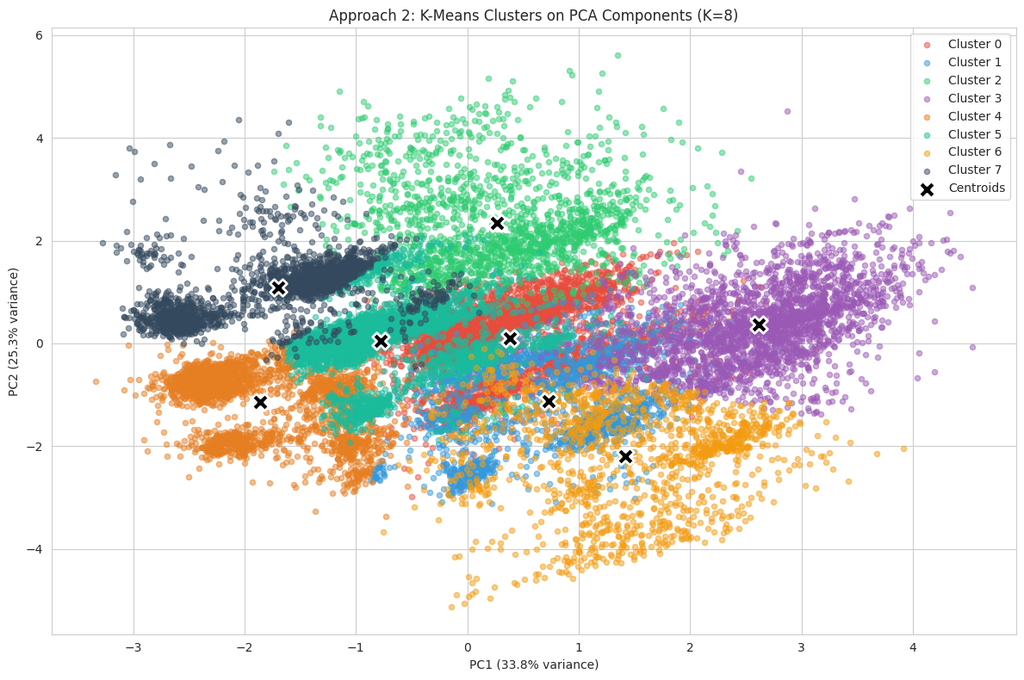

```python
# Visualize Approach 2 clusters
fig, ax = plt.subplots(figsize=(12, 8))

# Use first 2 PCA components for visualization
for cluster_id in range(optimal_k):
    mask = (cluster_labels_pca[sample_idx] == cluster_id)
    ax.scatter(
        X_pca[sample_idx, 0][mask],
        X_pca[sample_idx, 1][mask],
        c=CLUSTER_COLORS[cluster_id],
        label=f'Cluster {cluster_id}',
        alpha=0.5,
        s=20
    )

# Plot centroids (only first 2 components)
ax.scatter(kmeans_pca.cluster_centers_[:, 0], kmeans_pca.cluster_centers_[:, 1],
           c='black', marker='X', s=200, edgecolors='white', linewidths=2, label='Centroids')

ax.set_xlabel(f'PC1 ({pca_viz.explained_variance_ratio_[0]*100:.1f}% variance)')
ax.set_ylabel(f'PC2 ({pca_viz.explained_variance_ratio_[1]*100:.1f}% variance)')
ax.set_title(f'Approach 2: K-Means Clusters on PCA Components (K={optimal_k})')
ax.legend(loc='upper right')

plt.tight_layout()
plt.savefig(FIGURES_PATH / '04_standard_clusters_pca_approach2.png', dpi=150, bbox_inches='tight')
plt.show()
```

### 7.1 Compare Approach 1 vs Approach 2

```python
# Compare cluster assignments between approaches
from sklearn.metrics import adjusted_rand_score, normalized_mutual_info_score

ari = adjusted_rand_score(cluster_labels_original, cluster_labels_pca)
nmi = normalized_mutual_info_score(cluster_labels_original, cluster_labels_pca)

print("Comparison: Approach 1 (Original) vs Approach 2 (PCA)")
print("=" * 55)
print(f"  Adjusted Rand Index: {ari:.4f}")
print(f"  Normalized Mutual Information: {nmi:.4f}")
print(f"\nInterpretation:")
print(f"  ARI = 1.0 means identical clustering")
print(f"  ARI = 0.0 means random clustering")
if ari > 0.7:
    print(f"\n  Result: Both approaches produce SIMILAR clusters.")
elif ari > 0.4:
    print(f"\n  Result: Approaches have MODERATE agreement.")
else:
    print(f"\n  Result: Approaches produce DIFFERENT clusters - worth exploring both.")
```

```
Comparison: Approach 1 (Original) vs Approach 2 (PCA)
=======================================================
  Adjusted Rand Index: 0.7046
  Normalized Mutual Information: 0.7760

Interpretation:
  ARI = 1.0 means identical clustering
  ARI = 0.0 means random clustering

  Result: Both approaches produce SIMILAR clusters.
```

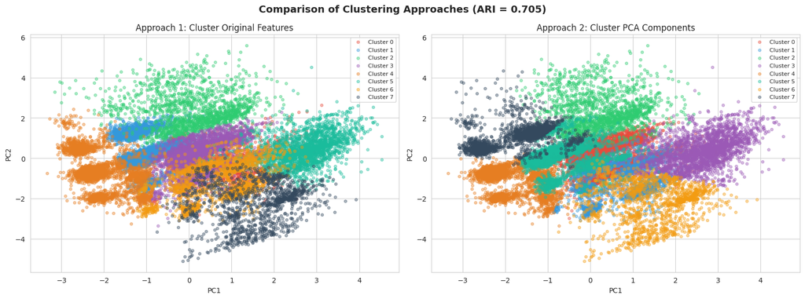

```python
# Side-by-side comparison visualization
fig, axes = plt.subplots(1, 2, figsize=(16, 6))

# Approach 1
for cluster_id in range(optimal_k):
    mask = (cluster_labels_original[sample_idx] == cluster_id)
    axes[0].scatter(
        X_pca_2d[sample_idx][mask, 0],
        X_pca_2d[sample_idx][mask, 1],
        c=CLUSTER_COLORS[cluster_id],
        label=f'Cluster {cluster_id}',
        alpha=0.4,
        s=15
    )
axes[0].set_xlabel('PC1')
axes[0].set_ylabel('PC2')
axes[0].set_title('Approach 1: Cluster Original Features')
axes[0].legend(loc='upper right', fontsize=8)

# Approach 2
for cluster_id in range(optimal_k):
    mask = (cluster_labels_pca[sample_idx] == cluster_id)
    axes[1].scatter(
        X_pca[sample_idx, 0][mask],
        X_pca[sample_idx, 1][mask],
        c=CLUSTER_COLORS[cluster_id],
        label=f'Cluster {cluster_id}',
        alpha=0.4,
        s=15
    )
axes[1].set_xlabel('PC1')
axes[1].set_ylabel('PC2')
axes[1].set_title('Approach 2: Cluster PCA Components')
axes[1].legend(loc='upper right', fontsize=8)

plt.suptitle(f'Comparison of Clustering Approaches (ARI = {ari:.3f})', fontsize=14, fontweight='bold')
plt.tight_layout()
plt.savefig(FIGURES_PATH / '04_standard_approach_comparison.png', dpi=150, bbox_inches='tight')
plt.show()
```

## 8. t-SNE Visualization

As per instructor warning: "t-SNE has stochastic behavior. Each run gives slightly different results."

We run t-SNE multiple times to identify robust patterns.

```python
# t-SNE on a sample (too slow for full dataset)
tsne_sample_size = 128000
np.random.seed(42)
tsne_idx = np.random.choice(len(X_scaled), tsne_sample_size, replace=False)

X_tsne_sample = X_scaled[tsne_idx]
labels_tsne_sample = cluster_labels_original[tsne_idx]

print(f"Running t-SNE on {tsne_sample_size:,} samples...")
print("This may take 1-2 minutes per run.")
```

```
Running t-SNE on 128,000 samples...
This may take 1-2 minutes per run.
```

```
Running t-SNE with random_state=42...
```

```
Running t-SNE with random_state=123...
```

```
Running t-SNE with random_state=456...
```

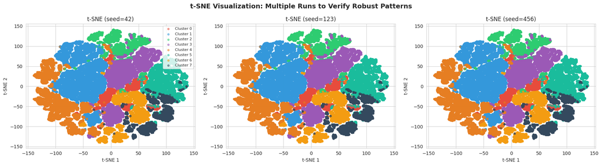

```
Note: t-SNE is for visualization only. Clusters are defined by K-Means.
Patterns that appear consistently across runs are robust.
```

```python
# Run t-SNE with 3 different random states to verify robustness
fig, axes = plt.subplots(1, 3, figsize=(18, 5))

random_states = [42, 123, 456]

for idx, rs in enumerate(random_states):
    print(f"Running t-SNE with random_state={rs}...")
    tsne = TSNE(n_jobs=-1, n_components=2, random_state=rs, perplexity=30, n_iter=1000)
    X_tsne = tsne.fit_transform(X_tsne_sample)

    # Plot
    for cluster_id in range(optimal_k):
        mask = (labels_tsne_sample == cluster_id)
        axes[idx].scatter(
            X_tsne[mask, 0],
            X_tsne[mask, 1],
            c=CLUSTER_COLORS[cluster_id],
            label=f'Cluster {cluster_id}',
            alpha=0.5,
            s=15
        )
    axes[idx].set_xlabel('t-SNE 1')
    axes[idx].set_ylabel('t-SNE 2')
    axes[idx].set_title(f't-SNE (seed={rs})')
    if idx == 0:
        axes[idx].legend(loc='upper right', fontsize=8)

plt.suptitle('t-SNE Visualization: Multiple Runs to Verify Robust Patterns', fontsize=14, fontweight='bold')
plt.tight_layout()
plt.savefig(FIGURES_PATH / '04_standard_tsne_multiple_runs.png', dpi=150, bbox_inches='tight')
plt.show()

print("\nNote: t-SNE is for visualization only. Clusters are defined by K-Means.")
print("Patterns that appear consistently across runs are robust.")
```

## 9. Cluster Interpretation

We analyze each cluster's characteristics and assign business-meaningful names.

```python
# Use Approach 1 clusters for interpretation (original features)
df_cluster['cluster'] = df_cluster['cluster_original']

# Calculate cluster profiles using original (non-transformed) values
profile_features = [
    'price_per_sqm',
    'building_size',
    'rooms_numeric',
    'has_elevator_binary',
    'has_parking_binary',
    'has_warehouse_binary',
    'city_price_level'
]

cluster_profiles = df_cluster.groupby('cluster')[profile_features].mean()

print("Cluster Profiles (Mean Values)")
print("=" * 80)
print(cluster_profiles.round(2).to_string())
```

```
Cluster Profiles (Mean Values)
================================================================================
         price_per_sqm  building_size  rooms_numeric  has_elevator_binary  has_parking_binary  has_warehouse_binary  city_price_level
cluster
0          29829691.41          98.39           1.95                 0.56                0.90                  0.00       26943690.59
1          37749720.29         113.61           2.22                 1.00                1.00                  1.00       28529721.61
2          39855640.60         260.06           3.53                 0.05                0.95                  0.97       24568249.57
3          30310371.63         102.20           1.75                 0.00                1.00                  1.00       24936233.38
4         115055269.47         105.22           2.08                 0.85                0.98                  0.95       85115877.69
5          22302258.29         263.89           1.97                 0.00                0.01                  0.01       23114573.78
6          33653720.58          76.13           1.51                 0.31                0.00                  1.00       41531065.92
7          85367929.58          70.76           1.01                 0.10                0.03                  0.00       41355850.17
```

```python
# Detailed cluster statistics
print("\nDetailed Cluster Statistics")
print("=" * 80)

for cluster_id in range(optimal_k):
    cluster_data = df_cluster[df_cluster['cluster'] == cluster_id]
    n = len(cluster_data)
    pct = n / len(df_cluster) * 100

    print(f"\nCluster {cluster_id} ({n:,} listings, {pct:.1f}% of market)")
    print("-" * 60)
    print(f"  Price/sqm:    Median = {cluster_data['price_per_sqm'].median()/1e6:.1f}M Tomans")
    print(f"  Size:         Median = {cluster_data['building_size'].median():.0f} sqm")
    print(f"  Rooms:        Median = {cluster_data['rooms_numeric'].median():.0f}")
    print(f"  Has Elevator: {cluster_data['has_elevator_binary'].mean()*100:.0f}%")
    print(f"  Has Parking:  {cluster_data['has_parking_binary'].mean()*100:.0f}%")
    print(f"  Has Storage:  {cluster_data['has_warehouse_binary'].mean()*100:.0f}%")
```

```
Detailed Cluster Statistics
================================================================================

Cluster 0 (32,244 listings, 6.9% of market)
------------------------------------------------------------
  Price/sqm:    Median = 26.0M Tomans
  Size:         Median = 90 sqm
  Rooms:        Median = 2
  Has Elevator: 56%
  Has Parking:  90%
  Has Storage:  0%

Cluster 1 (119,588 listings, 25.5% of market)
------------------------------------------------------------
  Price/sqm:    Median = 34.3M Tomans
  Size:         Median = 105 sqm
  Rooms:        Median = 2
  Has Elevator: 100%
  Has Parking:  100%
  Has Storage:  100%

Cluster 2 (40,825 listings, 8.7% of market)
------------------------------------------------------------
  Price/sqm:    Median = 26.4M Tomans
  Size:         Median = 220 sqm
  Rooms:        Median = 3
  Has Elevator: 5%
  Has Parking:  95%
  Has Storage:  97%
```

```
Cluster 3 (76,314 listings, 16.3% of market)
------------------------------------------------------------
  Price/sqm:    Median = 25.9M Tomans
  Size:         Median = 91 sqm
  Rooms:        Median = 2
  Has Elevator: 0%
  Has Parking:  100%
  Has Storage:  100%

Cluster 4 (69,104 listings, 14.8% of market)
------------------------------------------------------------
  Price/sqm:    Median = 101.2M Tomans
  Size:         Median = 93 sqm
  Rooms:        Median = 2
  Has Elevator: 85%
  Has Parking:  98%
  Has Storage:  95%

Cluster 5 (53,749 listings, 11.5% of market)
------------------------------------------------------------
  Price/sqm:    Median = 12.2M Tomans
  Size:         Median = 203 sqm
  Rooms:        Median = 2
  Has Elevator: 0%
  Has Parking:  1%
  Has Storage:  1%

Cluster 6 (45,104 listings, 9.6% of market)
------------------------------------------------------------
  Price/sqm:    Median = 25.0M Tomans
  Size:         Median = 72 sqm
  Rooms:        Median = 1
  Has Elevator: 31%
  Has Parking:  0%
  Has Storage:  100%

Cluster 7 (31,474 listings, 6.7% of market)
------------------------------------------------------------
  Price/sqm:    Median = 50.0M Tomans
  Size:         Median = 58 sqm
  Rooms:        Median = 1
  Has Elevator: 10%
  Has Parking:  3%
  Has Storage:  0%
```

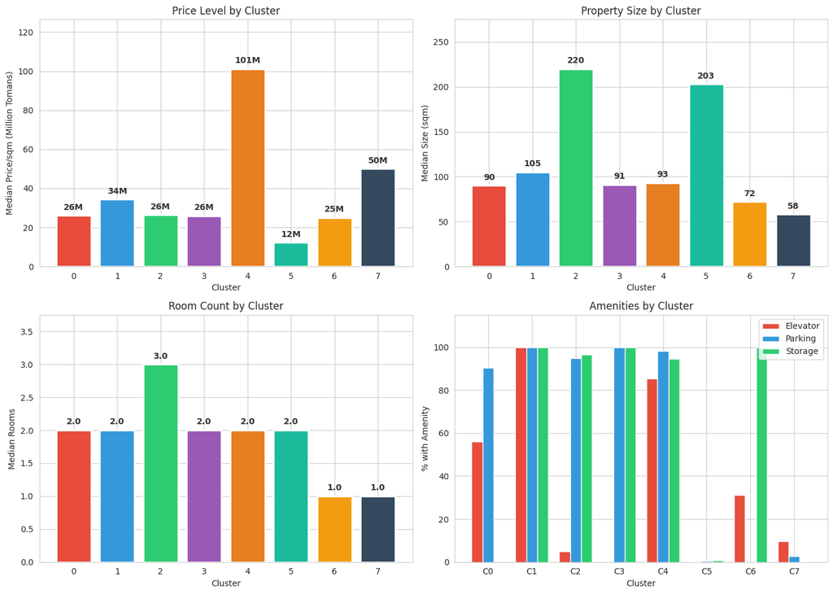

```python
# Visualize cluster profiles - labels ABOVE bars
fig, axes = plt.subplots(2, 2, figsize=(14, 10))

# 1. Price per sqm by cluster
cluster_price = df_cluster.groupby('cluster')['price_per_sqm'].median() / 1e6
bars = axes[0, 0].bar(range(optimal_k), cluster_price, color=CLUSTER_COLORS[:optimal_k], edgecolor='white', linewidth=2)
axes[0, 0].set_xlabel('Cluster')
axes[0, 0].set_ylabel('Median Price/sqm (Million Tomans)')
axes[0, 0].set_title('Price Level by Cluster')
axes[0, 0].set_xticks(range(optimal_k))
max_val = cluster_price.max()
axes[0, 0].set_ylim(0, max_val * 1.25)
for i, v in enumerate(cluster_price):
    axes[0, 0].text(i, v + max_val * 0.02, f'{v:.0f}M', ha='center', va='bottom', fontsize=10, fontweight='bold', color='#333333')

# 2. Building size by cluster
cluster_size = df_cluster.groupby('cluster')['building_size'].median()
bars = axes[0, 1].bar(range(optimal_k), cluster_size, color=CLUSTER_COLORS[:optimal_k], edgecolor='white', linewidth=2)
axes[0, 1].set_xlabel('Cluster')
axes[0, 1].set_ylabel('Median Size (sqm)')
axes[0, 1].set_title('Property Size by Cluster')
axes[0, 1].set_xticks(range(optimal_k))
max_val = cluster_size.max()
axes[0, 1].set_ylim(0, max_val * 1.25)
for i, v in enumerate(cluster_size):
    axes[0, 1].text(i, v + max_val * 0.02, f'{v:.0f}', ha='center', va='bottom', fontsize=10, fontweight='bold', color='#333333')

# 3. Rooms by cluster
cluster_rooms = df_cluster.groupby('cluster')['rooms_numeric'].median()
bars = axes[1, 0].bar(range(optimal_k), cluster_rooms, color=CLUSTER_COLORS[:optimal_k], edgecolor='white', linewidth=2)
axes[1, 0].set_xlabel('Cluster')
axes[1, 0].set_ylabel('Median Rooms')
axes[1, 0].set_title('Room Count by Cluster')
axes[1, 0].set_xticks(range(optimal_k))
max_val = cluster_rooms.max()
axes[1, 0].set_ylim(0, max_val * 1.25)
for i, v in enumerate(cluster_rooms):
    axes[1, 0].text(i, v + max_val * 0.02, f'{v:.1f}', ha='center', va='bottom', fontsize=10, fontweight='bold', color='#333333')

# 4. Amenities by cluster
amenity_cols = ['has_elevator_binary', 'has_parking_binary', 'has_warehouse_binary']
amenity_labels = ['Elevator', 'Parking', 'Storage']
x = np.arange(optimal_k)
width = 0.25

for i, (col, label) in enumerate(zip(amenity_cols, amenity_labels)):
    values = df_cluster.groupby('cluster')[col].mean() * 100
    axes[1, 1].bar(x + i*width, values, width, label=label, color=CLUSTER_COLORS[i], edgecolor='white', linewidth=1)

axes[1, 1].set_xlabel('Cluster')
axes[1, 1].set_ylabel('% with Amenity')
axes[1, 1].set_title('Amenities by Cluster')
axes[1, 1].set_xticks(x + width)
axes[1, 1].set_xticklabels([f'C{i}' for i in range(optimal_k)])
axes[1, 1].legend()
axes[1, 1].set_ylim(0, 115)

plt.tight_layout()
plt.savefig(FIGURES_PATH / '04_standard_cluster_profiles.png', dpi=150, bbox_inches='tight')
plt.show()
```

### 9.1 City Distribution per Cluster

```python
# Top cities in each cluster
print("Top 5 Cities in Each Cluster")
print("=" * 70)

for cluster_id in range(optimal_k):
    cluster_data = df_cluster[df_cluster['cluster'] == cluster_id]
    top_cities = cluster_data['city_slug'].value_counts().head(5)
    total = len(cluster_data)

    print(f"\nCluster {cluster_id}:")
    for city, count in top_cities.items():
        city_name = city.replace('-', ' ').title()
        pct = count / total * 100
        print(f"  {city_name:<25} {count:>8,} ({pct:>5.1f}%)")
```

```
Top 5 Cities in Each Cluster
======================================================================

Cluster 0:
  Tabriz                       3,379 ( 10.5%)
  Mashhad                      1,907 (  5.9%)
  Bandar Abbas                 1,836 (  5.7%)
  Parand City                  1,614 (  5.0%)
  Ahvaz                        1,597 (  5.0%)

Cluster 1:
  Mashhad                     13,772 ( 11.5%)
  Karaj                       12,258 ( 10.3%)
  Andisheh New Town            8,424 (  7.0%)
  Shiraz                       7,190 (  6.0%)
  Isfahan                      7,124 (  6.0%)

Cluster 2:
  Nur                          2,877 (  7.0%)
  Chamestan                    2,793 (  6.8%)
  Mashhad                      2,337 (  5.7%)
  Isfahan                      1,881 (  4.6%)
  Tehran                       1,746 (  4.3%)

Cluster 3:
  Andisheh New Town            5,325 (  7.0%)
  Karaj                        5,156 (  6.8%)
  Mashhad                      5,084 (  6.7%)
  Isfahan                      3,209 (  4.2%)
  Chamestan                    2,918 (  3.8%)
```

```
Cluster 4:
  Tehran                      66,282 ( 95.9%)
  Kish                         1,511 (  2.2%)
  Isfahan                        284 (  0.4%)
  Shiraz                         211 (  0.3%)
  Karaj                          167 (  0.2%)

Cluster 5:
  Mashhad                      2,108 (  3.9%)
  Isfahan                      2,062 (  3.8%)
  Shiraz                       1,896 (  3.5%)
  Karaj                        1,691 (  3.1%)
  Tabriz                       1,426 (  2.7%)

Cluster 6:
  Tehran                      11,858 ( 26.3%)
  Mashhad                      3,753 (  8.3%)
  Karaj                        3,544 (  7.9%)
  Tabriz                       2,021 (  4.5%)
  Qom                          1,057 (  2.3%)

Cluster 7:
  Tehran                       7,767 ( 24.7%)
  Mashhad                      2,636 (  8.4%)
  Tabriz                       2,000 (  6.4%)
  Karaj                        1,666 (  5.3%)
  Isfahan                      1,315 (  4.2%)
```

```python
# Tehran share in each cluster
print("\nTehran Presence in Each Cluster")
print("=" * 50)

for cluster_id in range(optimal_k):
    cluster_data = df_cluster[df_cluster['cluster'] == cluster_id]
    tehran_count = (cluster_data['city_slug'] == 'tehran').sum()
    tehran_pct = tehran_count / len(cluster_data) * 100
    print(f"Cluster {cluster_id}: {tehran_pct:.1f}% Tehran listings")
```

```
Tehran Presence in Each Cluster
==================================================
Cluster 0: 4.2% Tehran listings
```

```
Cluster 1: 0.7% Tehran listings
Cluster 2: 4.3% Tehran listings
Cluster 3: 2.4% Tehran listings
```

```
Cluster 4: 95.9% Tehran listings
Cluster 5: 2.5% Tehran listings
```

```
Cluster 6: 26.3% Tehran listings
Cluster 7: 24.7% Tehran listings
```

### 9.2 Assign Business-Meaningful Names

```python
# Build cluster summary for naming
cluster_summary = pd.DataFrame({
    'price_per_sqm': df_cluster.groupby('cluster')['price_per_sqm'].median(),
    'building_size': df_cluster.groupby('cluster')['building_size'].median(),
    'rooms': df_cluster.groupby('cluster')['rooms_numeric'].median(),
    'elevator_pct': df_cluster.groupby('cluster')['has_elevator_binary'].mean() * 100,
    'count': df_cluster.groupby('cluster').size()
})

# Add Tehran percentage
tehran_pcts = []
for cluster_id in range(optimal_k):
    cluster_data = df_cluster[df_cluster['cluster'] == cluster_id]
    tehran_pct = (cluster_data['city_slug'] == 'tehran').sum() / len(cluster_data) * 100
    tehran_pcts.append(tehran_pct)
cluster_summary['tehran_pct'] = tehran_pcts

print("Cluster Summary for Naming:")
print(cluster_summary.round(1).to_string())
```

```
Cluster Summary for Naming:
         price_per_sqm  building_size  rooms  elevator_pct   count  tehran_pct
cluster
0          26017838.80          90.00   2.00         55.90   32244        4.20
1          34320107.90         105.00   2.00        100.00  119588        0.70
2          26428571.40         220.00   3.00          5.00   40825        4.30
3          25882352.90          91.00   2.00          0.00   76314        2.40
4         101185789.30          93.00   2.00         85.40   69104       95.90
5          12250000.00         203.00   2.00          0.20   53749        2.50
6          25000000.00          72.00   1.00         31.20   45104       26.30
7          50000000.00          58.00   1.00          9.70   31474       24.70
```

```python
# Assign names based on characteristics
# Sort clusters by price to assign names logically
cluster_by_price = cluster_summary.sort_values('price_per_sqm', ascending=False).index.tolist()

cluster_names = {}
name_templates = [
    "Premium Properties",
    "Upper-Mid Market",
    "Standard Family Homes",
    "Mid-Range Apartments",
    "Budget Apartments",
    "Entry-Level Units",
    "Economy Segment",
    "Value Properties",
    "Starter Homes",
    "Basic Units"
]

for rank, cluster_id in enumerate(cluster_by_price):
    row = cluster_summary.loc[cluster_id]

    # Customize name based on characteristics
    if row['tehran_pct'] > 60:
        location = "Tehran "
    elif row['tehran_pct'] < 20:
        location = "Provincial "
    else:
        location = ""

    if row['building_size'] > 120:
        size_desc = "Spacious "
    elif row['building_size'] < 70:
        size_desc = "Compact "
    else:
        size_desc = ""

    base_name = name_templates[min(rank, len(name_templates)-1)]
    cluster_names[cluster_id] = f"{location}{size_desc}{base_name}".strip()

print("\nCluster Names (Business Interpretation):")
print("=" * 60)
for cluster_id in range(optimal_k):
    count = len(df_cluster[df_cluster['cluster'] == cluster_id])
    pct = count / len(df_cluster) * 100
    price = cluster_summary.loc[cluster_id, 'price_per_sqm'] / 1e6
    print(f"Cluster {cluster_id}: {cluster_names[cluster_id]}")
    print(f"           ({count:,} listings, {pct:.1f}%, {price:.0f}M Tomans/sqm)")
```

```
Cluster Names (Business Interpretation):
============================================================
Cluster 0: Provincial Budget Apartments
           (32,244 listings, 6.9%, 26M Tomans/sqm)
Cluster 1: Provincial Standard Family Homes
           (119,588 listings, 25.5%, 34M Tomans/sqm)
Cluster 2: Provincial Spacious Mid-Range Apartments
           (40,825 listings, 8.7%, 26M Tomans/sqm)
Cluster 3: Provincial Entry-Level Units
           (76,314 listings, 16.3%, 26M Tomans/sqm)
```

```
Cluster 4: Tehran Premium Properties
           (69,104 listings, 14.8%, 101M Tomans/sqm)
Cluster 5: Provincial Spacious Value Properties
           (53,749 listings, 11.5%, 12M Tomans/sqm)
Cluster 6: Economy Segment
           (45,104 listings, 9.6%, 25M Tomans/sqm)
Cluster 7: Compact Upper-Mid Market
           (31,474 listings, 6.7%, 50M Tomans/sqm)
```

```python
# Add cluster names to dataframe
df_cluster['cluster_name'] = df_cluster['cluster'].map(cluster_names)

# Final summary table
print("\n" + "=" * 80)
print("FINAL MARKET SEGMENTATION SUMMARY")
print("=" * 80)

for cluster_id in range(optimal_k):
    cluster_data = df_cluster[df_cluster['cluster'] == cluster_id]
    n = len(cluster_data)
    pct = n / len(df_cluster) * 100

    print(f"\n{cluster_names[cluster_id]} (Cluster {cluster_id})")
    print(f"  Count: {n:,} ({pct:.1f}%)")
    print(f"  Price/sqm: {cluster_data['price_per_sqm'].median()/1e6:.1f}M Tomans")
    print(f"  Size: {cluster_data['building_size'].median():.0f} sqm")
    print(f"  Elevator: {cluster_data['has_elevator_binary'].mean()*100:.0f}%")
```

```
================================================================================
FINAL MARKET SEGMENTATION SUMMARY
================================================================================

Provincial Budget Apartments (Cluster 0)
  Count: 32,244 (6.9%)
  Price/sqm: 26.0M Tomans
  Size: 90 sqm
  Elevator: 56%
```

```
Provincial Standard Family Homes (Cluster 1)
  Count: 119,588 (25.5%)
  Price/sqm: 34.3M Tomans
  Size: 105 sqm
  Elevator: 100%

Provincial Spacious Mid-Range Apartments (Cluster 2)
  Count: 40,825 (8.7%)
  Price/sqm: 26.4M Tomans
  Size: 220 sqm
  Elevator: 5%

Provincial Entry-Level Units (Cluster 3)
  Count: 76,314 (16.3%)
  Price/sqm: 25.9M Tomans
  Size: 91 sqm
  Elevator: 0%
```

```
Tehran Premium Properties (Cluster 4)
  Count: 69,104 (14.8%)
  Price/sqm: 101.2M Tomans
  Size: 93 sqm
  Elevator: 85%

Provincial Spacious Value Properties (Cluster 5)
  Count: 53,749 (11.5%)
  Price/sqm: 12.2M Tomans
  Size: 203 sqm
  Elevator: 0%
```

```
Economy Segment (Cluster 6)
  Count: 45,104 (9.6%)
  Price/sqm: 25.0M Tomans
  Size: 72 sqm
  Elevator: 31%

Compact Upper-Mid Market (Cluster 7)
  Count: 31,474 (6.7%)
  Price/sqm: 50.0M Tomans
  Size: 58 sqm
  Elevator: 10%
```

## 10. Cluster Size Distribution

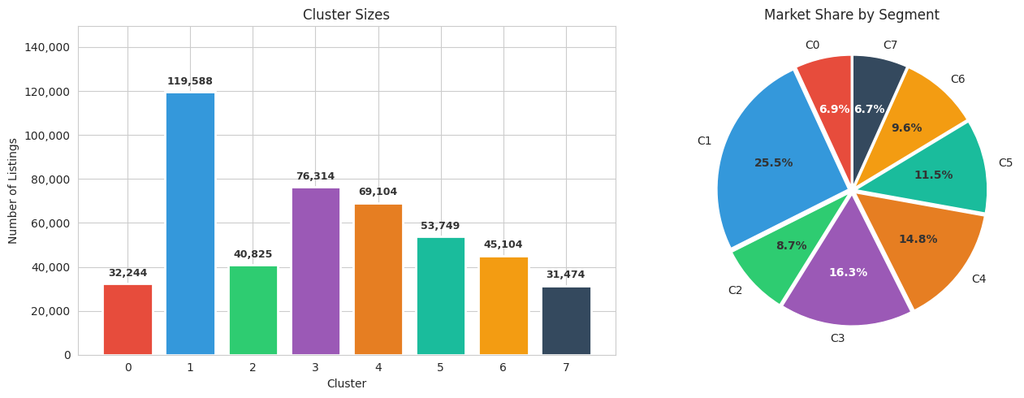

```python
# Visualize cluster distribution - labels ABOVE bars
fig, axes = plt.subplots(1, 2, figsize=(14, 5))

# Cluster sizes
cluster_sizes = df_cluster['cluster'].value_counts().sort_index()

# Left: Bar chart with labels ABOVE
bars = axes[0].bar(range(optimal_k), cluster_sizes, color=CLUSTER_COLORS[:optimal_k], edgecolor='white', linewidth=2)
axes[0].set_xlabel('Cluster')
axes[0].set_ylabel('Number of Listings')
axes[0].set_title('Cluster Sizes')
axes[0].set_xticks(range(optimal_k))
max_val = cluster_sizes.max()
axes[0].set_ylim(0, max_val * 1.25)
axes[0].yaxis.set_major_formatter(plt.FuncFormatter(lambda x, p: format(int(x), ',')))

for i, v in enumerate(cluster_sizes):
    axes[0].text(i, v + max_val * 0.02, f'{v:,}', ha='center', va='bottom', fontsize=9,
                 fontweight='bold', color='#333333')

# Right: Pie chart with adaptive text colors for visibility
labels = [f"C{i}" for i in range(optimal_k)]
wedges, texts, autotexts = axes[1].pie(cluster_sizes, labels=labels, autopct='%1.1f%%',
                                        colors=CLUSTER_COLORS[:optimal_k], startangle=90,
                                        explode=[0.03]*optimal_k)

# Function to determine if color is dark (needs white text)
def is_dark_color(color):
    import matplotlib.colors as mcolors
    rgb = mcolors.to_rgb(color)
    # Calculate luminance
    luminance = 0.299 * rgb[0] + 0.587 * rgb[1] + 0.114 * rgb[2]
    return luminance < 0.5

for i, autotext in enumerate(autotexts):
    autotext.set_fontsize(10)
    autotext.set_fontweight('bold')
    # Use white text for dark backgrounds, dark text for light backgrounds
    if is_dark_color(CLUSTER_COLORS[i]):
        autotext.set_color('white')
    else:
        autotext.set_color('#333333')

axes[1].set_title('Market Share by Segment')

plt.tight_layout()
plt.savefig(FIGURES_PATH / '04_standard_cluster_distribution.png', dpi=150, bbox_inches='tight')
plt.show()
```

## 11. Key Findings Summary

```python
print("=" * 70)
print("PHASE 4: KEY FINDINGS SUMMARY")
print("=" * 70)

print(f"""
CLUSTERING RESULTS
------------------
  Total listings clustered: {len(df_cluster):,}
  Number of clusters: {optimal_k}
  Best silhouette score: {max(silhouette_scores):.4f}

METHODOLOGY
-----------
  Features: 7 (price, size, rooms, amenities, city)
  City encoding: Target encoding (by median price)
  Normalization: StandardScaler
  Log transform: price_per_sqm, building_size, city_price_level
  Algorithm: K-Means (standard)

APPROACH COMPARISON
-------------------
  Approach 1 (Original Features): Primary results
  Approach 2 (PCA Components): {X_pca.shape[1]} components (90% variance)
  Adjusted Rand Index: {ari:.4f}
  Conclusion: {'Similar' if ari > 0.7 else 'Moderate agreement' if ari > 0.4 else 'Different'} cluster structures

MARKET SEGMENTS IDENTIFIED
--------------------------""")

for cluster_id in range(optimal_k):
    count = len(df_cluster[df_cluster['cluster'] == cluster_id])
    pct = count / len(df_cluster) * 100
    price = df_cluster[df_cluster['cluster'] == cluster_id]['price_per_sqm'].median() / 1e6
    print(f"  {cluster_id}. {cluster_names[cluster_id]}")
    print(f"     {count:,} listings ({pct:.1f}%), Median: {price:.0f}M Tomans/sqm")

print("\n" + "=" * 70)
```

```
======================================================================
PHASE 4: KEY FINDINGS SUMMARY
======================================================================

CLUSTERING RESULTS
------------------
  Total listings clustered: 468,402
  Number of clusters: 8
  Best silhouette score: 0.3123

METHODOLOGY
-----------
  Features: 7 (price, size, rooms, amenities, city)
  City encoding: Target encoding (by median price)
  Normalization: StandardScaler
  Log transform: price_per_sqm, building_size, city_price_level
  Algorithm: K-Means (standard)

APPROACH COMPARISON
-------------------
  Approach 1 (Original Features): Primary results
  Approach 2 (PCA Components): 5 components (90% variance)
  Adjusted Rand Index: 0.7046
  Conclusion: Similar cluster structures

MARKET SEGMENTS IDENTIFIED
--------------------------
  0. Provincial Budget Apartments
     32,244 listings (6.9%), Median: 26M Tomans/sqm
  1. Provincial Standard Family Homes
     119,588 listings (25.5%), Median: 34M Tomans/sqm
```

```
  2. Provincial Spacious Mid-Range Apartments
     40,825 listings (8.7%), Median: 26M Tomans/sqm
  3. Provincial Entry-Level Units
     76,314 listings (16.3%), Median: 26M Tomans/sqm
  4. Tehran Premium Properties
     69,104 listings (14.8%), Median: 101M Tomans/sqm
```

```
  5. Provincial Spacious Value Properties
     53,749 listings (11.5%), Median: 12M Tomans/sqm
  6. Economy Segment
     45,104 listings (9.6%), Median: 25M Tomans/sqm
  7. Compact Upper-Mid Market
     31,474 listings (6.7%), Median: 50M Tomans/sqm

======================================================================
```

## 12. Export Results

```python
# Save cluster assignments
export_cols = ['city_slug', 'price_per_sqm', 'building_size', 'rooms_numeric',
               'has_elevator_binary', 'has_parking_binary',
               'has_warehouse_binary', 'cluster', 'cluster_name']

df_cluster[export_cols].to_csv(DATA_PROCESSED / 'clustering_assignments_standard.csv', index=False)
print(f"Saved: clustering_assignments_standard.csv ({len(df_cluster):,} rows)")

# Save cluster profiles
cluster_profiles_export = df_cluster.groupby('cluster').agg({
    'price_per_sqm': ['median', 'mean', 'std'],
    'building_size': ['median', 'mean'],
    'rooms_numeric': ['median', 'mean'],
    'has_elevator_binary': 'mean',
    'has_parking_binary': 'mean',
    'has_warehouse_binary': 'mean',
    'city_slug': 'count'
}).round(2)

cluster_profiles_export.columns = ['_'.join(col).strip() for col in cluster_profiles_export.columns]
cluster_profiles_export['cluster_name'] = cluster_profiles_export.index.map(cluster_names)
cluster_profiles_export.to_csv(DATA_PROCESSED / 'cluster_profiles_standard.csv')
print(f"Saved: cluster_profiles_standard.csv")

# Save summary
summary_data = {
    'cluster': list(range(optimal_k)),
    'name': [cluster_names[i] for i in range(optimal_k)],
    'count': [len(df_cluster[df_cluster['cluster'] == i]) for i in range(optimal_k)],
    'median_price_per_sqm': [df_cluster[df_cluster['cluster'] == i]['price_per_sqm'].median() for i in range(optimal_k)],
    'median_size': [df_cluster[df_cluster['cluster'] == i]['building_size'].median() for i in range(optimal_k)]
}
pd.DataFrame(summary_data).to_csv(DATA_PROCESSED / 'clustering_summary_standard.csv', index=False)
print(f"Saved: clustering_summary_standard.csv")

print(f"\nAll figures saved to: {FIGURES_PATH}")
```

```
Saved: clustering_assignments_standard.csv (468,402 rows)
Saved: cluster_profiles_standard.csv
```

```
Saved: clustering_summary_standard.csv

All figures saved to: ./reports/figures
```

## 13. Conclusion

### Phase 4 Deliverables

| Output | Description |
| --- | --- |
| Optimal K selection | Elbow and Silhouette analysis |
| Approach 1 clusters | K-Means on original features |
| Approach 2 clusters | K-Means on PCA components |
| Approach comparison | ARI and visual comparison |
| t-SNE visualization | Multiple runs for robustness |
| Cluster profiles | Detailed statistics per cluster |
| Business names | Interpretable segment labels |
| City distribution | Geographic patterns per cluster |

### Files Created

- `clustering_assignments_standard.csv` - Full data with cluster labels
- `cluster_profiles_standard.csv` - Statistics per cluster
- `clustering_summary_standard.csv` - Summary table
- Figures: `04_*.png` in figures directory

### Key Insights

The real estate market naturally segments into distinct categories based on price, size, amenities, and location. These segments provide actionable intelligence:

- **For Buyers**: Identify which market segment matches your budget and needs
- **For Sellers**: Understand your competition within your segment
- **For Investors**: Spot opportunities in underserved segments

**Phase 4 Complete**

Proceed to **Phase 5: Price Prediction**